# 3.Proposal - ECO제주 모델링파일

UmStatistics - 권남택, 오정민, 유경민, 이상현

2021년 9월 15일 수요일

본 파일은 2021 빅콘테스트 ECO 제주 참가팀 **UmStatistics**의 마크다운 제출 파일입니다. 이 `Proposal` 파일에서는 정책제안을 위한 분석 파일들이 포함되어 있습니다. 이중차분법 디자인을 위한 클러스터링과 추세확인, 그리고 이상치 탐지를 위한 Shiny 결과를 확인합니다.

# 0. 사전 작업

## 0.1 라이브러리 로드와 함수

```r
library(tidyverse)    # 데이터 전처리
library(data.table)   # 데이터 전처리
library(lubridate)    # 시간 데이터 전처리
library(imputeTS)     # 시계열 결측치 보간
library(cluster)
library(factoextra)
library(gridExtra)
'%notin%' = Negate('%in%') # 함수 설정
```

## 0.2 워킹 디렉토리 설정

```r
CURRENT_WORKING_DIR <- dirname(rstudioapi::getActiveDocumentContext()$path)
CURRENT_WORKING_DIR
```

```
## [1] "C:/Users/Namtaek/Desktop/Submission/Additional_Submission_Files"
```

```r
setwd(CURRENT_WORKING_DIR)
```

## 0.3 데이터 불러오기

```r
daily_raw_data = fread('data/daily_imputed_joined_data.csv')
monthly_raw_data = fread('data/monthly_imputed_joined_data.csv')
```

# 1. 이중차분법 디자인

## 1.1 군집화

비슷한 행정동들을 먼저 묶고, 그 안에서 무작위 배정을 시행합니다.

```r
# 실루엣 계산 함수 설정
silhouette_score <- function(k, method){
  set.seed(0811)
  if (method=="kmeans"){clst <- kmeans(dat_clust, centers = k, nstart=25)}
  if (method == "kmedoids"){clst <- pam(dat_clust,k)}
  ss <- silhouette(clst$cluster, dist(dat_clust))
  mean(ss[, 3])
}

# 배출량/인구/카드사용량 변수
dong_data =
  daily_raw_data %>%
  mutate(float_pop = total_visit + total_work + total_resd + foreign_visit + foreign_resd + foreign_work ) %>%
  filter(yyyymm > "2020-01-01") %>%
  group_by(emd_nm) %>%
  summarise(em_g = mean(daily_em_g, na.rm=T),
            fpop = mean(float_pop),
            use_amt = mean(total_use_amt)) %>%
  filter(emd_nm!="알수없음")

# 스케일링
dat_clust = dong_data[,2:4] %>% scale()
```

해당 데이터를 통해 kmeans 클러스터링을 진행하고, 실루엣계수를 확인합니다. 실루엣 값이 0.5 이상인 경우 군집화가 잘 되었다고 판단합니다.

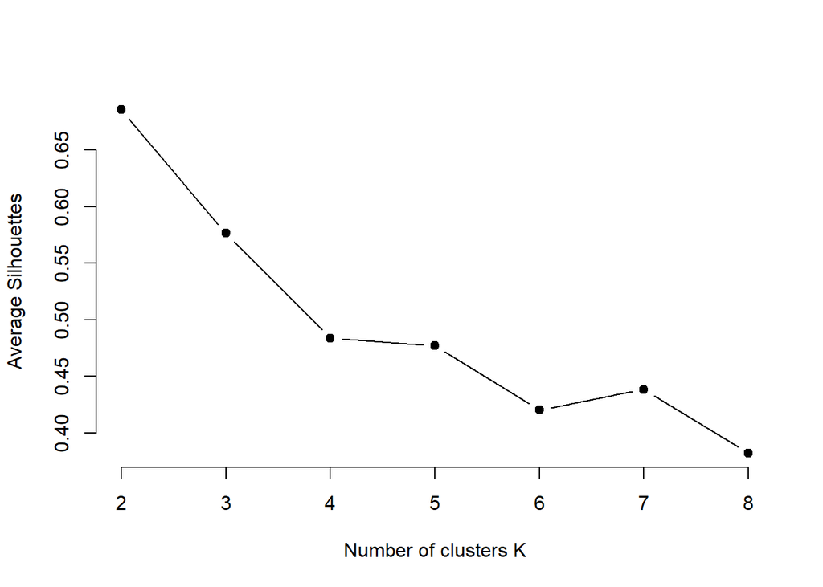

```r
set.seed(42)
k = 2:8
km_sil = sapply(k, silhouette_score, method = "kmeans")
km_k = k[which.max(km_sil)]

plot(k, km_sil,
     type = "b", pch = 19, frame = FALSE,
     xlab = "Number of clusters K",
     ylab = "Average Silhouettes")
```

```r
set.seed(42)
kmeans_result = kmeans(dat_clust, centers = 3)

dong_data$cluster = kmeans_result$cluster

dong_data %>% filter(cluster == 1)
```

```
## # A tibble: 16 x 5
##    emd_nm      em_g    fpop    use_amt cluster
##    <chr>      <dbl>   <dbl>      <dbl>   <int>
##  1 남원읍  2027349. 532886.  76750474.       1
##  2 대륜동  1557879. 536826.  91085917.       1
##  3 대정읍  3415855. 645860. 126115839.       1
##  4 대천동  1896761. 326559.  90858337.       1
##  5 동홍동  3575986. 646936. 161125149.       1
##  6 삼도1동 1906718. 379371. 103250801.       1
##  7 삼양동  3154972. 661054. 167480123.       1
##  8 성산읍  2009192. 541211.  63983423.       1
##  9 안덕면  1273807. 665192.  61208561.       1
## 10 오라동  1918517. 609733. 116751716.       1
## 11 외도동  3118858. 415356. 163084893.       1
## 12 용담2동 2011902. 528814. 102761015.       1
## 13 조천읍  1922850. 792933. 133915386.       1
## 14 중문동  2049451. 386294.  71755594.       1
## 15 한림읍  2398886. 750579. 100912584.       1
## 16 화북동  3591580. 849660. 169003197.       1
```

```r
dong_data %>% filter(cluster == 2)
```

```
## # A tibble: 6 x 5
##   emd_nm      em_g     fpop    use_amt cluster
##   <chr>      <dbl>    <dbl>      <dbl>   <int>
## 1 노형동  7936728. 1857387. 454714522.       2
## 2 아라동  3774293. 1377326. 246159099.       2
## 3 애월읍  3071857. 1419859. 198810779.       2
## 4 연동    6154601. 1651703. 360209688.       2
## 5 이도2동 7150088. 1851859. 377476167.       2
## 6 일도2동 4892444.  903935. 227971428.       2
```

```r
dong_data %>% filter(cluster == 3)
```

```
## # A tibble: 19 x 5
##    emd_nm      em_g    fpop   use_amt cluster
##    <chr>      <dbl>   <dbl>     <dbl>   <int>
##  1 건입동  1265887. 331455. 71941994.       3
##  2 구좌읍  1026161. 521449. 61306034.       3
##  3 도두동   583736. 104731. 22284261.       3
##  4 봉개동   514425. 211645. 27329977.       3
##  5 삼도2동 1008452. 240454. 58157186.       3
##  6 서홍동  1380222. 242339. 79718805.       3
##  7 송산동   789291.  86308. 26879130.       3
##  8 영천동  1378240. 197868. 31141988.       3
##  9 예래동   530954. 229607. 24222645.       3
## 10 용담1동 1054345. 248495. 50275971.       3
## 11 이도1동 1378103. 414810. 63259913.       3
## 12 이호동   687741. 156424. 28037342.       3
## 13 일도1동  578544.  94573. 24102349.       3
## 14 정방동   723286. 140954. 14877576.       3
## 15 중앙동  1493696. 158329. 26848582.       3
## 16 천지동  1114380.  63456. 25524394.       3
## 17 표선면  1084202. 390500. 47962099.       3
## 18 한경면   730136. 267013. 34090439.       3
## 19 효돈동   860432. 136639. 29280215.       3
```

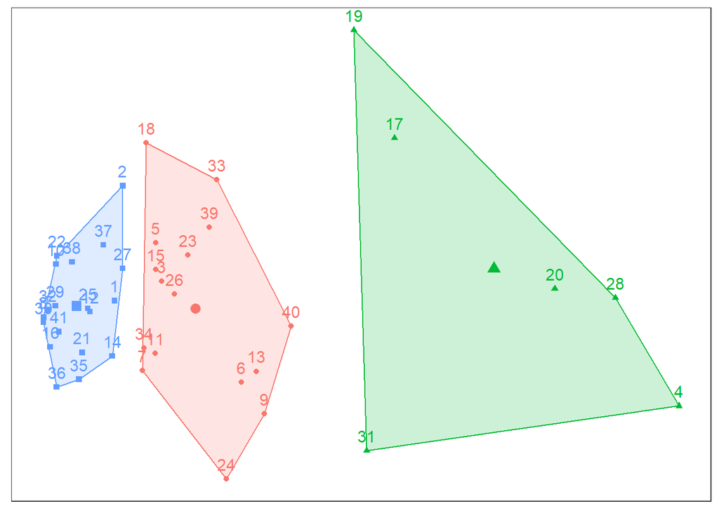

```r
fviz_cluster(kmeans_result, data = dat_clust) +
  theme_bw() +
  theme(panel.grid.major.x = element_blank(), panel.grid.minor.x = element_blank(),
        panel.grid.major.y = element_blank(), panel.grid.minor.y = element_blank(),
        axis.ticks.x=element_blank(), axis.text.x=element_blank(), axis.title.x=element_blank(),
        axis.ticks.y=element_blank(), axis.text.y=element_blank(), axis.title.y=element_blank(),
        plot.title = element_blank(),legend.position="none")
```

클러스터링 결과가 상당히 잘 나왔습다.

## 1.2 무작위 배정

클러스터링의 결과로 생긴 행정동들 안에서 무작위 배정을 통해 처지집단과 통제집단을 분리합니다. 랜덤성을 통제하는 것도 잊지 않습니다.

```r
cluster1_dong_name = dong_data %>% filter(cluster == 1) %>% .$emd_nm
cluster2_dong_name = dong_data %>% filter(cluster == 2) %>% .$emd_nm
cluster3_dong_name = dong_data %>% filter(cluster == 3) %>% .$emd_nm

set.seed(42)
cluster1_dong_treated = cluster1_dong_name %>% sample(length(cluster1_dong_name)/2) %>% sort()
cluster2_dong_treated = cluster2_dong_name %>% sample(length(cluster2_dong_name)/2) %>% sort()
cluster3_dong_treated = cluster3_dong_name %>% sample(length(cluster3_dong_name)/2) %>% sort()

cluster1_dong_control = cluster1_dong_name %>% setdiff(cluster1_dong_treated)
cluster2_dong_control = cluster2_dong_name %>% setdiff(cluster2_dong_treated)
cluster3_dong_control = cluster3_dong_name %>% setdiff(cluster3_dong_treated)

dong_treated = c(cluster1_dong_treated, cluster2_dong_treated, cluster3_dong_treated)
dong_control = c(cluster1_dong_control, cluster2_dong_control, cluster3_dong_control)
```

이후 처치집단은 빨간색, 통제집단은 초록색으로 색을 설정하고, 평행 추세 가정(Parallel Trend Assumption)을 확인합니다.

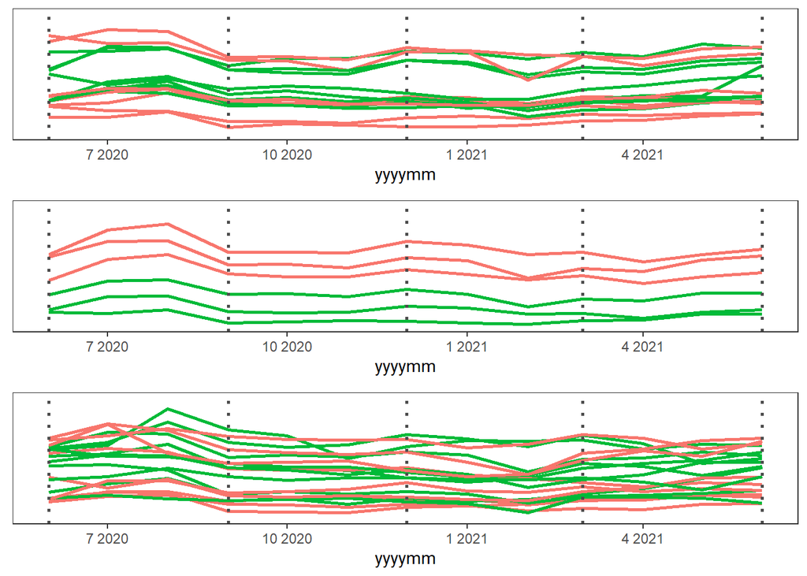

```r
# 색 설정
cluster1_color = ifelse(cluster1_dong_name %in% cluster1_dong_treated, '#F8766D', '#00BA38')
cluster2_color = ifelse(cluster2_dong_name %in% cluster2_dong_treated, '#F8766D', '#00BA38')
cluster3_color = ifelse(cluster3_dong_name %in% cluster3_dong_treated, '#F8766D', '#00BA38')

# 시각화
cluster1_plot =
  monthly_raw_data %>% filter(emd_nm %in% cluster1_dong_name) %>%
  select(yyyymm, emd_nm, monthly_em_g) %>%
  mutate(assignment = ifelse(emd_nm %in% dong_treated, 'treated', 'control')) %>%
  ggplot() +
  geom_line(aes(x = yyyymm, y = monthly_em_g, color = emd_nm), size = 1) +
  scale_color_manual(values = cluster1_color) +
  geom_vline(xintercept = as.Date('2020-06-01'), linetype = 3, size = 1, color = 'gray30') +
  geom_vline(xintercept = as.Date('2020-09-01'), linetype = 3, size = 1, color = 'gray30') +
  geom_vline(xintercept = as.Date('2020-12-01'), linetype = 3, size = 1, color = 'gray30') +
  geom_vline(xintercept = as.Date('2021-03-01'), linetype = 3, size = 1, color = 'gray30') +
  geom_vline(xintercept = as.Date('2021-06-01'), linetype = 3, size = 1, color = 'gray30') +
  xlim(as.Date('2020-06-01'), as.Date('2021-06-01')) +
  theme_bw() +
  theme(panel.grid.major.x = element_blank(), panel.grid.minor.x = element_blank(),
        panel.grid.major.y = element_blank(), panel.grid.minor.y = element_blank(),
        #axis.ticks.x=element_blank(), axis.text.x=element_blank(), axis.title.x=element_blank(),
        axis.ticks.y=element_blank(), axis.text.y=element_blank(), axis.title.y=element_blank(),
        plot.title = element_blank(),legend.position="none")

cluster2_plot =
  monthly_raw_data %>% filter(emd_nm %in% cluster2_dong_name) %>%
  select(yyyymm, emd_nm, monthly_em_g) %>%
  mutate(assignment = ifelse(emd_nm %in% dong_treated, 'treated', 'control')) %>%
  ggplot() +
  geom_line(aes(x = yyyymm, y = monthly_em_g, color = emd_nm), size = 1) +
  scale_color_manual(values = cluster2_color) +
  geom_vline(xintercept = as.Date('2020-06-01'), linetype = 3, size = 1, color = 'gray30') +
  geom_vline(xintercept = as.Date('2020-09-01'), linetype = 3, size = 1, color = 'gray30') +
  geom_vline(xintercept = as.Date('2020-12-01'), linetype = 3, size = 1, color = 'gray30') +
  geom_vline(xintercept = as.Date('2021-03-01'), linetype = 3, size = 1, color = 'gray30') +
  geom_vline(xintercept = as.Date('2021-06-01'), linetype = 3, size = 1, color = 'gray30') +
  xlim(as.Date('2020-06-01'), as.Date('2021-06-01')) +
  theme_bw() +
  theme(panel.grid.major.x = element_blank(), panel.grid.minor.x = element_blank(),
        panel.grid.major.y = element_blank(), panel.grid.minor.y = element_blank(),
        #axis.ticks.x=element_blank(), axis.text.x=element_blank(), axis.title.x=element_blank(),
        axis.ticks.y=element_blank(), axis.text.y=element_blank(), axis.title.y=element_blank(),
        plot.title = element_blank(),legend.position="none")

cluster3_plot =
  monthly_raw_data %>% filter(emd_nm %in% cluster3_dong_name) %>%
  select(yyyymm, emd_nm, monthly_em_g) %>%
  mutate(assignment = ifelse(emd_nm %in% dong_treated, 'treated', 'control')) %>%
  ggplot() +
  geom_line(aes(x = yyyymm, y = monthly_em_g, color = emd_nm), size = 1) +
  scale_color_manual(values = cluster3_color) +
  geom_vline(xintercept = as.Date('2020-06-01'), linetype = 3, size = 1, color = 'gray30') +
  geom_vline(xintercept = as.Date('2020-09-01'), linetype = 3, size = 1, color = 'gray30') +
  geom_vline(xintercept = as.Date('2020-12-01'), linetype = 3, size = 1, color = 'gray30') +
  geom_vline(xintercept = as.Date('2021-03-01'), linetype = 3, size = 1, color = 'gray30') +
  geom_vline(xintercept = as.Date('2021-06-01'), linetype = 3, size = 1, color = 'gray30') +
  xlim(as.Date('2020-06-01'), as.Date('2021-06-01')) +
  theme_bw() +
  theme(panel.grid.major.x = element_blank(), panel.grid.minor.x = element_blank(),
        panel.grid.major.y = element_blank(), panel.grid.minor.y = element_blank(),
        #axis.ticks.x=element_blank(), axis.text.x=element_blank(), axis.title.x=element_blank(),
        axis.ticks.y=element_blank(), axis.text.y=element_blank(), axis.title.y=element_blank(),
        plot.title = element_blank(),legend.position="none")

grid.arrange(cluster1_plot, cluster2_plot, cluster3_plot, nrow = 3)
```

전체적으로 보았을때, 클러스터 안에서 움직임이 비슷합니다. 따라서 평행추세 가정이 만족되었음을 확인 가능합니다.

# 2. 이상치 탐지 Shiny 구현

해당 코드를 .R 파일에서 실행하면 정상적으로 작동합니다. 현재 청크에서는 `eval=F`로 설정하였습니다. 궁금한 날짜를 선택하면 이상치 여부를 알려주는 방식입니다.

```r
shiny::runGitHub("Umstatistics", "Kyungmin-Yu", ref="main" )
```